# Ejercicios de Python

**Objetivo del notebook**  
Plantilla para que puedas entregar tus **respuestas** de los ejercicios de Python. Los ejercicios están separados por secciones.

**Pasos de implementación**

- Variables
- Funciones
- Ciclos
- Índices y Slicing

**Datos de entrada**

No Aplica

**Entregable**

1. Crear una copia en Drive ( Archivo > Guardar una copia en mi drive)
2. Contestar los ejercicios en el notebook que creaste
3. Subir el notebook en esta Tarea,
4. Esperar evalación del notebook, se tarda en revisar tu tarea un día

**NOTA**: Usa los nombres de variables que se indican en cada ejercicio

## variables

### Ejercicio variables 1

Crea la variable “mi_primer_variable” y asigna en ella el valor de 10

```python
mi_primer_variable=10
```

### Ejercicio variables 2

Crea la variable “mi_segunda_variable” y asigna en ella el valor de 9

```python
mi_segunda_variable=9
```

### Ejercicio variables 3

Crea la variable “mi_tercera_variable” y asigna en ella el valor resultante de sumar "mi_primer_variable" y "mi_segunda_variable"

```python
mi_tercera_variable=mi_primer_variable+mi_segunda_variable
```

```python
print(mi_tercera_variable)
```

```
19
```

## Funciones

### Ejercicio funciones 1

Crea la función "suma" que reciba dos parámetros y devuelva el resultado de sumar el primer parámetro y segundo parámetro. Ejemplo de uso de la función:

```
{python}
suma(12, 10)
```

y el resultado deberá ser 22

Recuerda la sintaxis para crear una función

```
{python}
def nombre_funcion(param1, param2):
  #fragmento de código asociado a param1, param2
  return valores_respuesta #el return es opcional
```

```python
def sumar (a,b):
    suma=a+b
    return suma
z=sumar(12,14)
print(z)
```

```
26
```

### Ejercicio funciones 2

Crea la función "calculadora" que reciba tres parámetros (x, y, tipo_operacion) y devuelva el resultado de aplicar "tipo_operacion" a "x" y "y".  
Utiliza la columna para nombrar el "tipo_operacion", es decir si "tipo_operacion" tiene el valor de Addition usa el operador +.

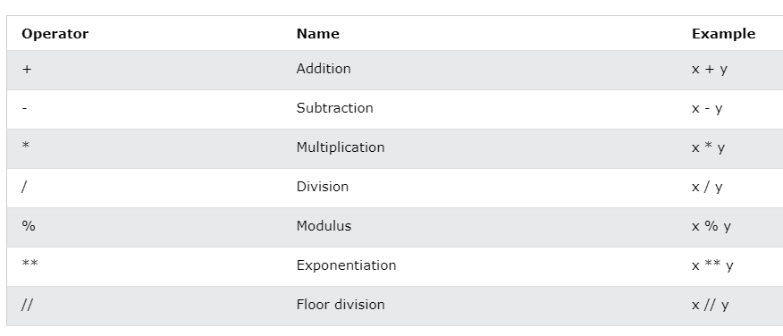

Ejemplo de uso de la función:

```
{python}
calculadora(12, 10, "Addicion")
```

regresa: 22

**Nota**: Para las funciones Division, Modulus, Exponentiation, Floor division el orden importa. Ejemplo

```
{python}
calculadora(12, 10, "Division") # 1.2
#Es diferente a
calculadora(10, 12, "Division") # 0.8333333333333334
```

Y también recuerda que int/0 no esta definido, en caso de que dividas por 0 o uses módulo 0 (división, división entera, módulo) regresa el mensaje **No puedes dividir por cero** para la división y **No esta definido módulo cero** para el módulo Recuerda la sintaxis para crear una función

```
{python}
def nombre_funcion(param1, param2):
  #fragmento de código asociado a param1, param2
  return valores_respuesta #el return es opcional
```

```python
def sub1(a,b):
    c = a-b
    return c
```

### Ejercicio funciones 3

Crea la función "rango" que reciba una lista y devuelva una tupla con el máximo y mínimo

```
{python}
rango([12, 10, 13, 30, 100])
```

regresa: (100, 10)

Recuerda la sintaxis para crear una función

```
{python}
def nombre_funcion(param1, param2):
  #fragmento de código asociado a param1, param2
  return valores_respuesta #el return es opcional
```

```python
rango = ([12, 10, 13, 30, 100])
def mayor(rango):
    max = rango[0];
    for x in rango:
        if x > max:
            max = x
    return max

def menor(rango):
    min = rango[0];
    for x in rango:
        if x < min:
            min = x
    return min

def main(rango):
    print ( mayor(rango))
    print (menor(rango))
    print ( max(rango))
    print ( min(rango))

main(rango)
```

```
100
10
100
10
```

## Ciclos

### Ejercicios ciclos 1

Crea la función "gen_pares", que reciba un parámetro entero y genere una secuencia del 0 **al número ingresado**, regrese sólo los números pares, debes utilizar **for**. Ejemplo:

```
{python}
gen_pares(10)
```

regresa: 0,2,4,6,8,10

```python
igen_par=[10]
pares=[0,2,4,6,8]
for a in range(len(igen_par)):
    pares.append(igen_par[a])
    print(pares)
```

```
[0, 2, 4, 6, 8, 10]
```

```python
from math import sqrt #quise realizar con la sqrt pero no pude sacar los impares
mx=10
par=[(a,b, sqrt(a*2 + b+2))
     for a in range(2, mx) for b in range(a, mx)]
par = [(a, b, int(c)) for a, b, c in par if c.is_integer()]
print(par)
```

```
[(2, 3, 3), (3, 8, 4), (4, 6, 4), (7, 9, 5)]
```

### Ejercicios ciclos 2

Crea la función "repetir_nombre", que reciba los siguientes parámetros:

- cadena: una cadena de texto
- rep: entero y genere una lista con la cadena repetida *rep*-veces

```python
def repetir_nombre(lista, veces): #se crea por medio del estamento listas y despues se duplica el elemento de la lista
    salida = []
    for elemento in lista:
        salida.extend([elemento] * veces)
    return salida


a=["Gabriel"]

print(repetir(a, 2))
```

[output not shown]

### Ejercicios ciclos 3

Crea la función "repetir_nombre", que reciba los siguientes parámetros:

- cadena: una cadena de texto
- rep: entero y genere una lista con la cadena repetida *rep*-veces

  ```
  {python}
  repetir_nombre("Gabriel", 2)
  ```

  regresa: ["Gabriel", "Gabriel"]

```python
repetir_nombre= ["Gabriel"] #Duplicado via operador de multiplicacion
print(repetir_nombre * 2)
```

```
['Gabriel', 'Gabriel']
```

## Índices y Slicing

### Ejercicios índices y slicing 1

Crear la función "tercer_elemento" que reciba los siguientes parámetros:

- lista: lista con elementos
- indice: índice.

y que regrese el elemento en el índice "indice", en caso de que el "indice" supere el número de elementos en la lista devuelve el mensaje "Error de índice, no puede seleccionar un índice que no está en la lista". Ejemplo:

```
{python}
lista = [1,2,3,4]
tercer_elemento(lista, indice = 2)
```

[3]

```python
lista=[1,2,3,4]
indice=lista[0]
tercer_elemento=print(lista,indice)
print(tercer_elemento)
```

```
[1, 2, 3, 4] 1
None
```

### Ejercicios índices y slicing 2

Crear la función "slicing" que reciba los siguientes parámetros:

- lista: lista con elementos
- inicio: inicio del slicing
- fin: fin del slicing
- salto: saltos entre índices y replique el comportamiento en slicing en una lista. Ejemplo:

  ```
  {python}
  lista = [1,2,3,4]
  slicing(lista, inicio = 0, fin = 3, salto = 2)
  ```

  [1, 3]

```python
lista=[1,2,3,4]
inicio=lista[0]
fin=lista[len(lista)-1]
salto=lista[0:3]
slicing=print(lista,inicio,fin,salto)
```

```
[1, 2, 3, 4] 1 4 [1, 2, 3]
```

### Ejercicios índices y slicing 3

Crear la función "voltear" que reciba los siguientes parámetros:

- lista: lista con elementos.  
  y replique el comportamiento en slicing en una lista para invertir el nombre. Ejemplo:

  ```
  {python}
  lista = [1,2,3,4]
  voltear(lista)
  ```

  [4, 3, 2, 1]

```python
lista=[1,2,3,4]
voltear=lista[::-1]
```

```python
print(voltear)
```

```
[4, 3, 2, 1]
```